# Estimating Rc

David Smith

10/12/2020

## Introduction

### Reproductive Success

Reproductive numbers are a useful way of measuring malaria transmission intensity. Reproductive numbers are frequently used to describe infectious diseases, but they are also used in other contexts. In general, reproductive numbers are used to describe an organism’s reproductive success. The term was first used in human demography by Alfred J Lotka, who defined $R_0$ as the number of human females that would be born to a single human female over her lifetime. Lotka also wrote the definitive mathematical analysis of Ronald Ross’s models of malaria transmission. George Macdonald, who was undoubtedly aware of Lotka’s work, adapted the idea of a reproductive number to describe malaria transmission. In 1952, he presented a formula the *sporozoite rate* in terms of a few key entomological parameters. Later that year, he introduced the idea of a reproductive number and a formula for it. Those papers, the concepts, and the formulas had an enduring effect on malaria epidemiology and mathematical epidemiology.

For parasites and pathogens, reproductive success is not measured by reproduction within a host, but by transmission to new hosts. For human malaria parasites, we would count reproductive success starting from a human index case and follows the parasites through mosquitoes and back to other infected humans. We could also start counting when a mosquito became infected, following the parasites through infective bites and all the humans infected, and then counting how many other mosquitoes became infected by those parasites after blood feeding. Either way, we define malaria reproductive numbers as the expected number of human malaria infections that would arise from each human malaria infection after one complete parasite generation.

Malaria transmission in most places has been modified by malaria control. To describe baseline transmission, we use the basic reproductive number, denoted $R_0$. By baseline, we mean something very specific: we mean reproductive success in a population with no malaria control under conditions that would prevail if there were no malaria immunity. For malaria, there is some malaria immunity and some malaria control in place almost everywhere. To deal with control, we define a more general term called the adjusted reproductive number, denoted $R_C$, that is like $R_0$ in every way except control: it measures reproductive success with no malaria immunity but with control. The subscript $C$ can stand for a complex set of interventions at various levels of coverage. We will discuss $R_C$ throughout because it is the general term. The basic reproductive number is the special case when there is no control, when $C=0$. (We will discuss malaria immunity later.)

For example, if $R_C=2$, then each human infected with malaria parasites would infect two other humans. Malaria parasites would tend to increase if they were rare, and malaria would become endemic. If $R_C=0.5$, then it would take two infected humans to infect one other human. If malaria cases were imported into such a place, they would be always dying out. A threshold condition for sustained malaria transmission, in the absence of malaria importation, is thus that $R_C>1$. Below this level, malaria can not establish endemic transmission. Above this level, malaria is likely to be endemic.

The utility of these threshold concepts is modified by parasite mobility in infected humans and mosquitoes. Malaria is present in many places because humans move around, and malaria can persist for a few years after malaria transmission has been suppressed. In measuring $R_C$, we would like to know whether malaria transmission could be sustained *here* and *now* if all malaria importation ceased. We are also interested in quantifying malaria connectivity and persistence in large interconnected regions. All these concepts require having sound estimates of local transmission. When we discuss $R_C$, we are discussing the concept of a local $R_C$, a measure of reproductive success as if there were no mobility.

Despite the complexity, we will continue to use simple formulas, we will stick with the biological definition of *generation* as defined by the parasite’s life-cycle. In describing transmission, we will rely heavily on the concept of a yearly average in an area. We will do most of our arithmetic on these arithmetic averages, but we are developing utilities that translate these yearly averages into threshold criteria for malaria persistence when there is heterogeneous biting, when transmission is seasonal, and when transmission is spatially heterogeneous and poorly mixed in an area. We always count from a human to humans, or sometimes from a mosquito to mosquitoes. We will be consistent about treating reproductive success as an arithmetic expectation at a point in time and space. In general, we will take $R_C$ as a measure of what would happen in an area if it were closed to migration – we interested in quantifying what would happen *here* and *now*, but we will interpret those measures in light of heterogeneity.

### Formulas

Mosquitoes transmit malaria parasites through blood feeding. One of George Macdonald’s enduring contributions to the world was to give names to the parameters describing mosquito behavior and assemble them into formulas for the *sporozoite rate* and $R_0$. Despite the familiarity and utility of that formula, we will use a different one. We prefer a very general and simple formula to describe $R_C$. To count all human infections arising from a single, human index case. We define three steps:

- Once a human becomes infected, we need to know how long the infection lasts and how infectious the person would be over time. Since human infections vary in duration, and since infectiosness is variable over time, we need a single number that counts all of it up in a reasonable way. Here, we use the term **human transmitting capacity** (HTC or $D$) to stand for this concept. The units of HTC are days, and we interpret it as a number of days being fully infectious. For example, 200 days of infecting 20% of mosquitoes would add up to 40 fully infectious days.
- The number of infective mosquito bites that would eventually arise from all the mosquitoes blood feeding on a single fully infectious person on a single day is called **vectorial capacity** (VC or $V$), or alternatively, the *daily reproductive number*. The concept of VC can thuse be defined in even the most complicated models: VC can generally be computed on each day for each individual, but to be useful at a population level, we will take an average.
- The total number of infective bites arising per infected human is thus the product, $VD$. Not every infective bite causes an infection. The ratio of infectious bites to infections is called **transmission efficiency** ($b$).

In discussing $R_C$ we stipulate that all these terms are defined at an ambient levels of control: we thus write $V_C$ and $D_C$ and $b_C$ and we use the general formula:

$$R_C = b V_C D_C$$
For those who are interested, the tabs below delve into these concepts in some detail. Otherwise, the next concept is an *effect size*.

#### Vectorial Capacity (VC or $V$)

In the original paper on vectorial capacity, it was described as a *daily reproductive rate*. More precisely, it is defined as an expectation:

*Vectorial capacity* is defined to be *the expected number of infectious bites arising from all the mosquitoes blood feeding on a single human on a single day as if a human were perfectly infectious*

In computing vectorial capacity, we will work from the assumption that it is an average over all the humans in a population, and that it has been averaged over some time period.

To deal with complex patterns of human infectiousness to mosquitoes, the stipulation that humans were *perfectly infectious* was added to make a clear separation between humans and mosquitoes. This is clearly defined above. Those problematic concerns are discussed in the section on the Human Transmitting Capacity (HTC).

More relevant for mosquitoes, we need our definition of vectorial capacity to apply in places where there are several vector species present, or perhaps when there are multiple types (*e.g.* insecticide resistance). In general, then, we will assume that total vectorial capacity $V$ is a sum over the vectorial capacity of many types $V_i$.

In translating from the HTC, we must confront a critical question of how infectious humans are to members of each one of those species. What factors, aside from the parameters named by Macdonald, affect whether a mosquito would become infective after blood feeding on a human that is perfectly infectious? Or to put it another way, if it is perfectly infectious to a perfectly competent vector? Vector competence does not include the probability a mosquito would survive the EIP, but it does include all the mosquito, mosquito-parasite, and environmental factors that determine whether parasite would infect the mosquito and complete its development.

In the standard notation we have developed, we have that:

$$V_i = c_i \frac{f_i^2 Q_i^2}{g_i^2}e^{-g_i n_i} = c_i \lambda_i s_i^2 P_i$$
and

$$V=\sum_i V_i.$$

#### Human Transmitting Capacity (HTC or $D$)

Human transmitting capacity is defined as an expected number of days infectious. Using malaria therapy data, we estimated $D_0 \approx 32$ fully infectious days.

- Johnston, G. L., Smith, D. L., & Fidock, D. A. (2013). Malaria’s missing number: calculating the human component of $R_0$ by a within-host mechanistic model of *Plasmodium falciparum* infection and transmission. PLoS Computational Biology, 9(4), e1003025.
- Johnston, G. L., Gething, P. W., Hay, S. I., Smith, D. L., & Fidock, D. A. (2014). Modeling within-host effects of drugs on *Plasmodium falciparum* transmission and prospects for malaria elimination. PLoS Computational Biology, 10(1), e1003434. *******

#### Transmission Efficiency ($b$)

We estimate $b \approx 0.55$ using data from controlled human malaria infections. We note that most of these challenges were made with *An. stephansi*.

- Smith, D. L., Drakeley, C. J., Chiyaka, C., & Hay, S. I. (2010). A quantitative analysis of transmission efficiency versus intensity for malaria. Nature Communications, 1(8), 108. *******

### Effect Size

Malaria transmission dynamics, epidemiology, and control are complex. Transmission intensity is a key concept, but we also need a complementary way of understanding malaria control. One advantage of using reproductive numbers is that they translate easily into measures of the **effect size** on transmission intensity, which we define as a *fold*-reduction.

An effect size is thus a ratio, and we can also partition the total effect size of control into its effects on transmission:
$$\frac{R_0}{R_C} = \frac{b_0 V_0 D_0}{b_C V_C D_C}$$
The effect size of vector control on VC is $V_0/V_C$, the effect size of drugs on HTC is $D_0/D_C$. The effect size of a pre-erythrocytic vaccine is $b_0/b_C$. In defining an effect size in this way, we can make some observations:

- The effect sizes of different modes of control with independent effects is multiplicative.
  - For example, if drugs reduce transmission by 50% (an effect size of 2), and vector control reduces transmission by 90% (an effect size of 10), then the total reduction is 95% (an effect size of 20).
- $R_0$ describes the total effect size required to eliminate malaria.
  - To eliminate malaria on reasonable time scales, an effect size larger than $2 R_0$ might be required.
- $R_C$ describes the marginal effect size required to eliminate malaria in addition to all the other interventions currently in place.

## $R_C$ for Programs

### Why use $R_C$?

Programmatically, there are many metrics that could be used as a basis for describing transmission intensity, and each one has some advantages and disadvantages. The advantages of using $R_C$ are:

1. $R_C$ conveys information about malaria transmission intensity across the whole spectrum of transmission intensity.
2. $R_C$ has an intuitive interpretation.
3. $R_C$ provides a useful metric for planning malaria control.
4. The use of $R_0$ and $R_C$ emphasizes a difference between the baseline conditions and modification by control.

The challenge for using $R_C$ is establishing a reasonable set of guidelines about how, when, and where to measure it. Similar challenges apply to using any metric of transmission programmatically. There is no single measure of malaria transmission intensity that is useful across the spectrum. If there were a metric that could be used everywhere and in every context, we would favor it. Since malaria varies so much, there will be some place or time or context when every metric is inaccurate. To be useful, programs must either adopt something like $R_C$, or they must use multiple metrics. In fact, $R_C$ estimates are generally derived from other metrics.

Some alternative metrics commonly used to measure malaria transmission intensity are the entomological inoculation rate (EIR), the parasite rate (PR), or case counts from routine surveillance translated into the annual parasite index (API). We will discuss each one of these metrics in the sections that follow. In very low transmission settings, where malaria is maintained by importation, a good measure of transmission intensity is the ratio of imported to local cases, which is translated into a measure of the parasite’s reproductive success by a simple formula. Most importantly, all of these metrics apply to malaria transmission *under present conditions*, but many programmatic decisions involve understanding what would happen under a set of hypotheticals. The most common programmatic decision involves planning malaria control in places that already have some vector control or case managment in place. The world with vector control is measured by $R_C$, while the one without is measured by $R_0$. It can be a disaster to make decisions about the world now without considering how the world would be otherwise.

### EIR

In many ways, the EIR is the ideal measure of local transmission intensity because it measures malaria exposure risk at a particular time and place. Because mosquitoes are short-lived, the epidemiology of infection in mosquitoes is simple and free from concerns about immunity. Because mosquitoes fly short distances, it is an accurate measure of transmission in an area.

Objections to using the EIR are all practical. It is expensive to measure the EIR accurately. The cost of measuring it accurately increases at low transmission intensity. To catch 10 sporozoite positive mosquitoes when the annual EIR is one, it would take 10 person years of sampling.

### PR

The PR is a commonly used metric, but since people move around and infections last a long time, it can be a highly misleading metric of local transmission intensity. In areas where risk is highly heterogeneous, people who carry parasites and live *here* could be infected because they traveled *there*.

### API

### Case Ratios

## Understanding $R_C$

### VC $\rightarrow$ EIR

The tradtional approach to VC was to estimate the parameters in Macdonald’s formula. That approach proved challenging for several reasons, so we have adopted a different approach: we estimate the VC from the EIR.

The EIR and the VC are different sides of the same coin. On the one hand, the EIR measures the number of infectious bites *received by* a single person on a single day. On the other hand, the VC is the number of infectious bites *arising from* a single person on a single day. The main difference in the definitions is that the VC is computed as if everyone was perfectly infectious, while the EIR is measured in a place where the net infectiousness (NI, and denoted $\kappa$), is defined as the probability a mosquito would become infected after blood feeding on a human. The two quantities must approximately balance out (ignoring mosquito migration). A basic formula for the two is:

$$E = V \frac{\kappa}{1 + s \kappa}$$

It follows that

$$V = \frac{E \left( 1 + s\kappa \right)}{\kappa}$$

The term $1+s\kappa$ is a measure of how many times mosquitoes are super-infected. The term $s$ here is defined to be the number of human blood meals, per mosquito (*i.e.* summed over an average mosquito lifespan). The higher $s$, the greater the fraction of mosquitoes that would have been infected more than once. In some settings, $s$ could be as high as 4 or 5, but it will tend to be much lower. The number $\kappa$, on the other hand, is a probability, a number bounded between $0$ and $1$. It tends to be less than $1/5$. It thus seems likely that in most settings, $1< 1+s \kappa < 2$. As we will see, both the variability in $R_C$ and uncertainty about $R_C$ are enormous, so in context, this ends up being a comparatively small quantity.

We offer the following heuristic. The EIR is approximately the product of VC and NI:

$$E \approx V \kappa$$
In other words, the number of infectious bites received (EIR) is approximately equal to the number of infectious bites arising (VC) computed as if every mosquito became infected times the proportion of mosquitoes that actually became infected. If we know the EIR, then VC is computed as:

$$V \approx \frac{E}{\kappa}$$
This could present computational challenges when $\kappa$ is very small.

- Smith, D. L., McKenzie, F. E., Snow, R. W., & Hay, S. I. (2007). Revisiting the basic reproductive number for malaria and its implications for malaria control. PLoS Biology, 5(3), e42.

### EIR $\rightarrow$ PR

While the EIR is measured infrequently, the PR is routinely measured in cross-sectional surveys. We can use the PR to estimate the EIR based on an empirical relationship between the EIR and the PR. Here, we start by re-examining an old database describing the EIR and the PR.

As a prelude, we start with a study sought to model the relationship between the EIR and the PR using mechanistic models (Smith, *et al.*, 2005):

$$x = 1 - \left( 1 + \frac{b E k}{r}\right)^{-1/k}$$

In many ways, we consider this functional form to be a sort of upper bound since it includes super-infection but ignores drug treatment. The parameter $k$ builds in some flexibility. As $k$ becomes very large, heterogeneity plays a larger role. As $k$ becomes very small, the model is equivalent to Ross-Macdonald dynamics. In some sense, we take this as a strong prior on the data. One way it would *not* be an upper bound is if there were a substantial amount of exposure from outside the area, an idea we will explore later.

Here are the data (black points), the log-linear fits, and the function, with different values of $k$. The higher the green curve, the smaller $k$.

We were concerned about bias in the EIR estimates. In particular, we were suspicious of the points around aEIR of 1 that were above our green curves. We noted that these points came from four studies, and we further examined these studies to quantify a house effect. On the bases of those house effects (see below), we made some corrections.

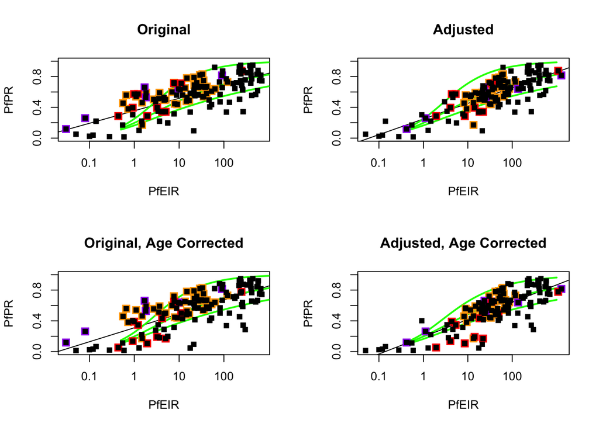

#### House Effects

If the functional form is, indeed, an upper bound then we must be concerned about points that are above the curve. In a previous analysis (see Fig. 2a in Penny, *et al.*, 2015), we identified systematic differences in the relationship based on the method of sampling mosquitoes. Given concerns about sampling bias, we tried to tried to identify which studies they came from. We found the following:

- One set came from Thomson (red points and the red fitted line).
- Two sets of studies came from around Killifi. One is a thesis by Kabiru, and the other a study by Mbogo (orange).
- One set came from Bodker (purple).
- The final set plotted below includes all the other studies not included in one of those sets (black):

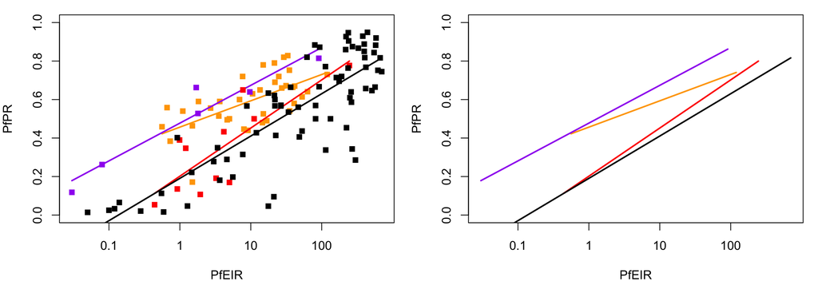

##### Kilifi House Effect

The house effect of Kabiru / Mbogo is a factor of $11$ at the lowest intensity, but declining by a factor of 3.2 for every factor of $10$ increase in the EIR.

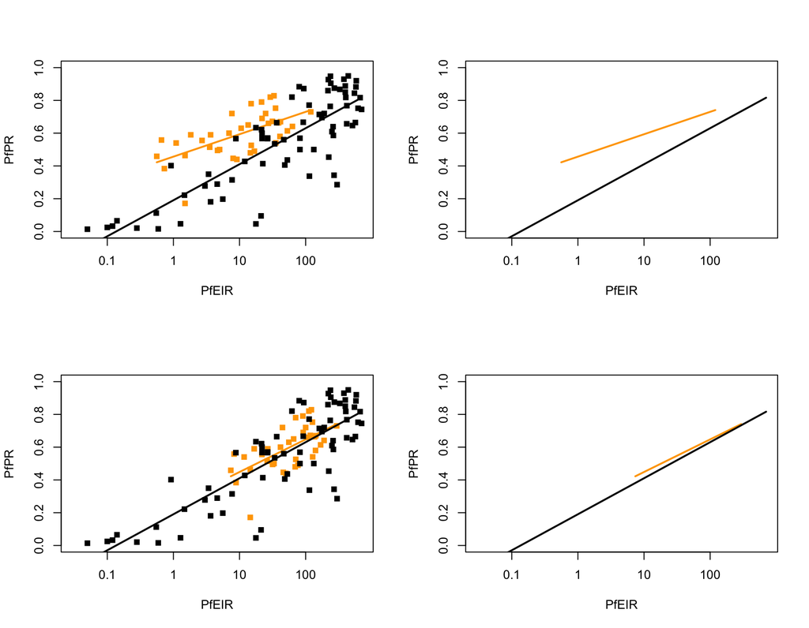

##### Thomson House Effect

The study by Thomson reports that they divided their estimates by a factor of 4.4, so we shift it back. Below, we have plotted the EIR estimates that were higher by a factor of 4.4 to reflect what was measured.

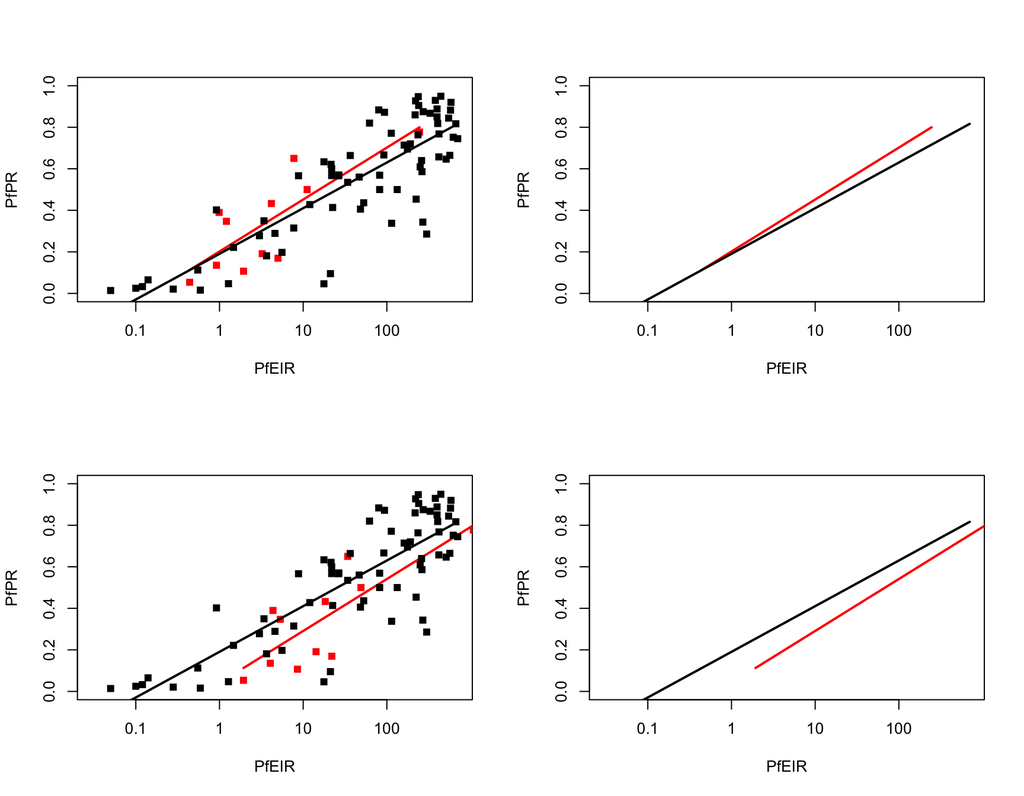

##### Bodker House Effect

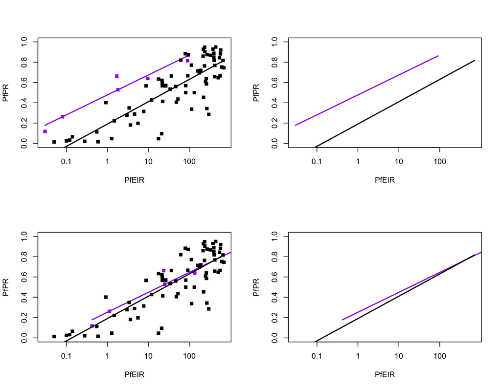

##### CDC Light Traps

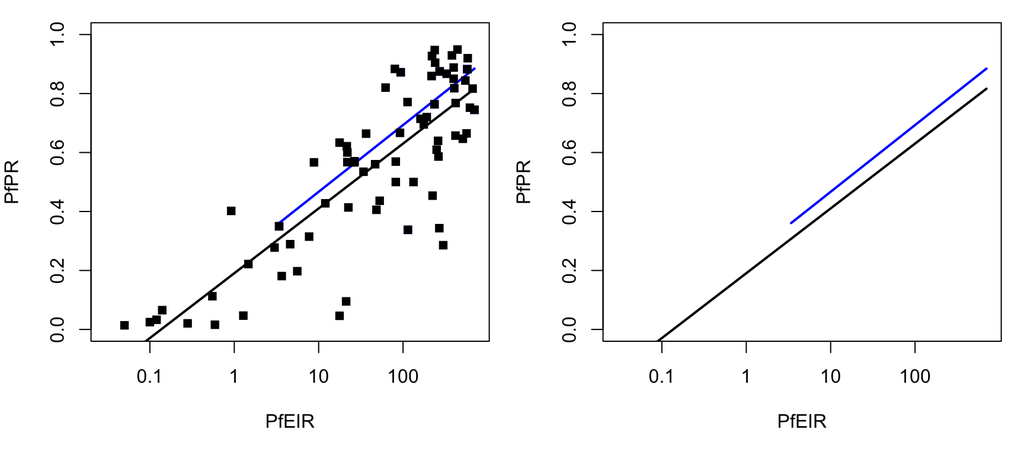

#### Revised Data

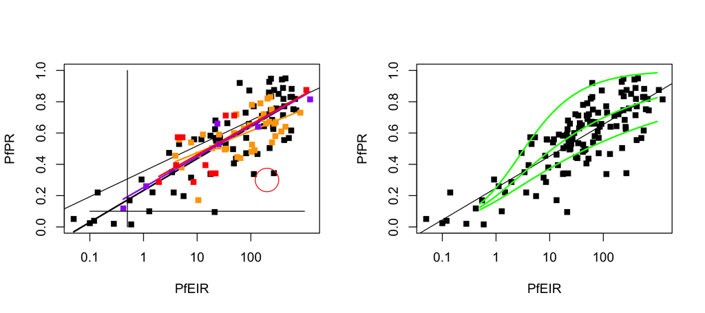

```r
coef(llin2)
```

```
## (Intercept)      NewEIR
##   0.2486121   0.2034227
```

**References**

- Smith, D. L., Dushoff, J., Snow, R. W. & Hay, S. I. The entomological inoculation rate and Plasmodium falciparum infection in African children. Nature 438, 492–495 (2005)
- Smith, D. L., McKenzie, F. E., Snow, R. W. & Hay, S. I. Revisiting the basic reproductive number for malaria and its implications for malaria control. PLoS Biol. 5, e42 (2007)
- Penny, M. A. et al. Distribution of malaria exposure in endemic countries in Africa considering country levels of effective treatment. Malar. J. 14, 384 (2015)

### EIR $\rightarrow$ FoI

In this study, the conversion from EIR to FOI is not relevant. Using dynamic maps, it would be.

**References**

- Smith, D. L., Drakeley, C. J., Chiyaka, C. & Hay, S. I. A quantitative analysis of transmission efficiency versus intensity for malaria. Nat. Commun. 1, 108 (2010)

### PR $\rightarrow$ NI

The net infectiousness of humans to mosquitoes (NI, denoted $\kappa$) is a probability, $0 < \kappa < 1$. To become infected after feeding on a human, that human must be infectious, which is a function of the PR ($x$).

Most of the evidence used to estimate $\kappa$ comes from estimates of the sporozoite rate. In Macdonald’s model, this is:
$$z = \frac{s \kappa}{1+s\kappa}P$$
where $P$ is the proportion of mosquitoes surviving the EIP. Inverting, we get that
$$\kappa = \frac{z}{s (P-z)}$$

We will assume that $z \propto x$, or more generally, we will assume it is a non-linear function:
$$z = F_\kappa(x).$$

For example:

$$z = k_1 x e^{-k_2 x}.$$

so

$$\kappa = \frac{z}{s (P-z)}.$$

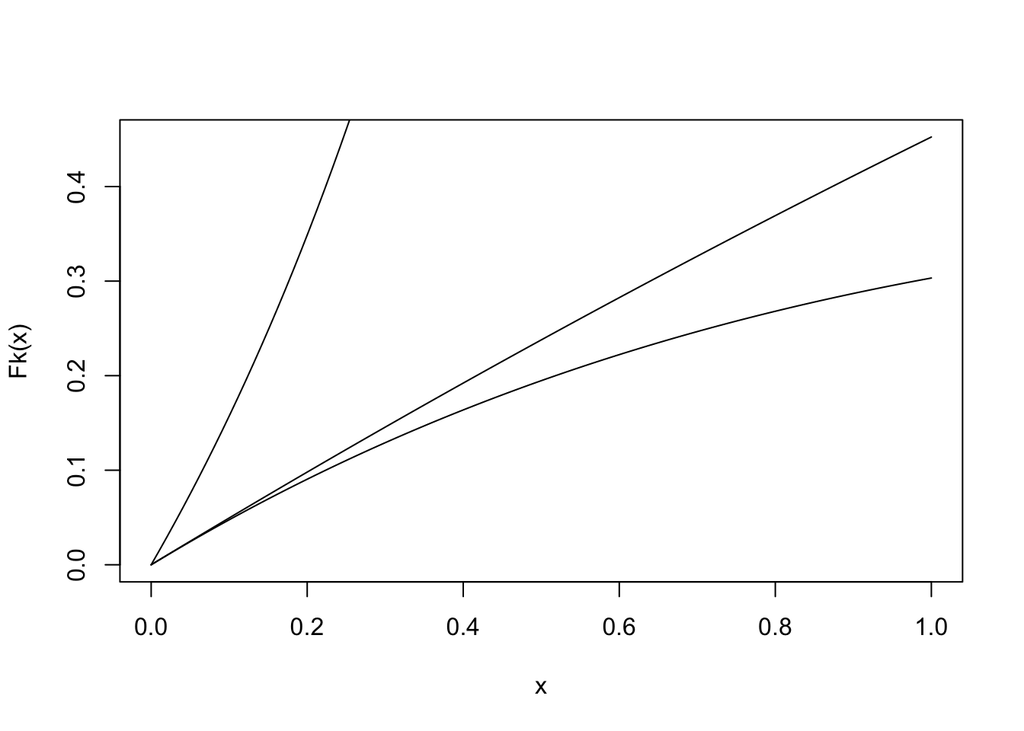

```r
Fk = function(x, k1=.5, k2=.1, s=1, P=0.35){
  k1*x*exp(-k2*x)
}

Fkappa = function(x, k1=.5, k2=.1, s=1, P=0.35){
  z = k1*x*exp(-k2*x)
  z/(s*(P-z))
}
z2kappa = function(z, s=1, P=0.35){
  z/(s*(P-z))
}

x = seq(0,1,length.out=100)
plot(x, Fk(x), type ="l")
lines(x, Fk(x, k2=.5), type ="l")
lines(x, Fkappa(x, k2=.5), type ="l")
```

[figure not shown]

```r
par(mfrow = c(2,1))
prsr = read.csv("prVsr.csv")
ix = which(prsr$SR2>0)
prk = c(prsr$PR,prsr$PR[ix], .31, .2, .1)
srk = c(prsr$SR1,prsr$SR2[ix], 2.2, 2.5, 1.5)/100
plot(prk, srk, xlim = c(0,1), ylim = c(0,.25), pch =15, xlab = expression(x), ylab = expression(z))
llm = lm(srk~prk+0)
lines(x, Fk(x, k1=0.1, k2=0), col = "blue")
lines(x, Fk(x, k1=.15, k2=0.8), col = "blue")

kk = z2kappa(srk)
plot(prk, kk, xlim = c(0,1), ylim = c(0,1), pch =15, xlab = expression(x), ylab = expression(kappa))
llmk = lm(kk~prk+0)
#lines(x, Fkappa(x, k1=0.2, k2=0, P=0.1), col = "blue")
lines(x, Fkappa(x, k1=0.1, k2=0, P=0.2), col = "blue")
lines(x, Fkappa(x, k1=0.1, k2=0, P=0.4), col = "blue")
```

[output not shown]

```r
#lines(x, Fkappa(x, k1=0.5, k2=0, P=0.2), col = "blue")
#lines(x, Fkappa(x, k1=0.1, k2=0, P=0.4), col = "blue")
```

```r
#lines(x, Fkappa(x, k1=.15, k2=0.8, P=0.2), col = "blue")
```

- Tusting, L. S., Bousema, T., Smith, D. L., & Drakeley, C. (2014). Measuring changes in Plasmodium falciparum transmission: precision, accuracy and costs of metrics. Advances in Parasitology, 84, 151–208.
- Mbogo, C. M., Mwangangi, J. M., Nzovu, J., Gu, W., Yan, G., Gunter, J. T., Swalm, C., Keating, J., Regens, J. L., Shililu, J. I., Githure, J. I., & Beier, J. C. (2003). Spatial and temporal heterogeneity of Anopheles mosquitoes and Plasmodium falciparum transmission along the Kenyan coast. The American Journal of Tropical Medicine and Hygiene, 68(6), 734–742.
- Thomson, M. C., D’Alessandro, U., Bennett, S., Connor, S. J., Langerock, P., Jawara, M., Todd, J., & Greenwood, B. M. (1994). Malaria prevalence is inversely related to vector density in The Gambia, West Africa. Transactions of the Royal Society of Tropical Medicine and Hygiene, 88(6), 638–643.

### Space

**References**